# Looking back

Peter Ralph

11 March 2021 – Advanced Biological Statistics

# Looking back

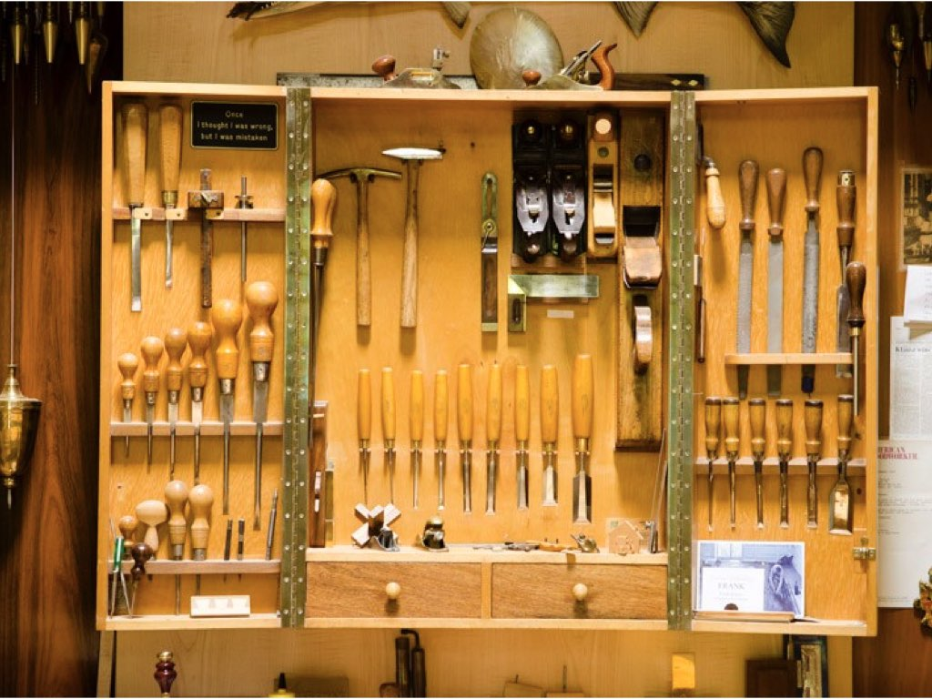

a box of tools

## Steps in data analysis

1. Care, or at least think, about the data.
2. Look at the data.
3. Query the data.
4. Check the answers.
5. Communicate.

[figure not shown]

impostor syndrome

## Statistics or parameters?

**A **statistic** is**

a numerical description of a dataset.

**A **parameter** is**

a numerical attribute of a model of reality.

Often, *statistics* are used to estimate *parameters*.

## Lurking, behind everything:

is *uncertainty*

thanks to *randomness*.

How do we understand randomness, concretely and quantitatively?

With *models*.

## Statistics

**statistics** are numerical summaries of data,

**parameters** are numerical attributes of a model.

- confidence intervals
- $p$-values
- report effect sizes!
- statistical significance does not imply real-world significance
- Central Limit Theorems:
  - sums of many independent sources of noise gives a Gaussian
  - count of many rare, independent events is Poisson

## Experimental design

- experiment versus observational study
- controls, randomization, replicates
- samples: from what population?
- statistical power : $\sigma/\sqrt{n}$
- confounding factors
- correlation versus causation

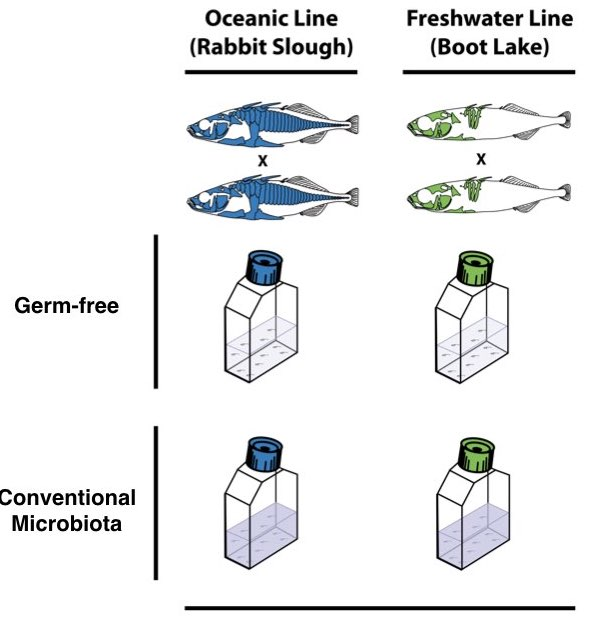

## Tidy data

- readable
- descriptive
- documented
- columns are variables, rows are observations
- semantically coherent

## Visualization

- makes precise visual analogies
- with real units
- labeled
- maximize information per unit ink

## Concepts and skills

- $z$-scores and $t$-tests
- ANOVA: ratios of mean-squares
- Kaplan-Meier survival curves
- Cox proportional hazard models
- smoothing: `loess`
- multiple comparisons: Bonferroni; FDR
- the bootstrap - resampling
- conditional probability
- simulation
- simulation
- oh, and simulation
- power analysis
- permutation tests
- goodness of fit
- crossvalidation
- imputation and interpolation
- nonidentifiability

# Randomness: deal with it

## Distributions

- Normal (a.k.a, Gaussian)
- logNormal
- scale mixtures of Normals
- multivariate Normal
- Student’s $t$
- the $F$ distribution
- Beta
- Binomial
- Beta-Binomial
- Exponential
- Gamma
- Cauchy
- Poisson
- Weibull
- chi-squared
- Dirichlet

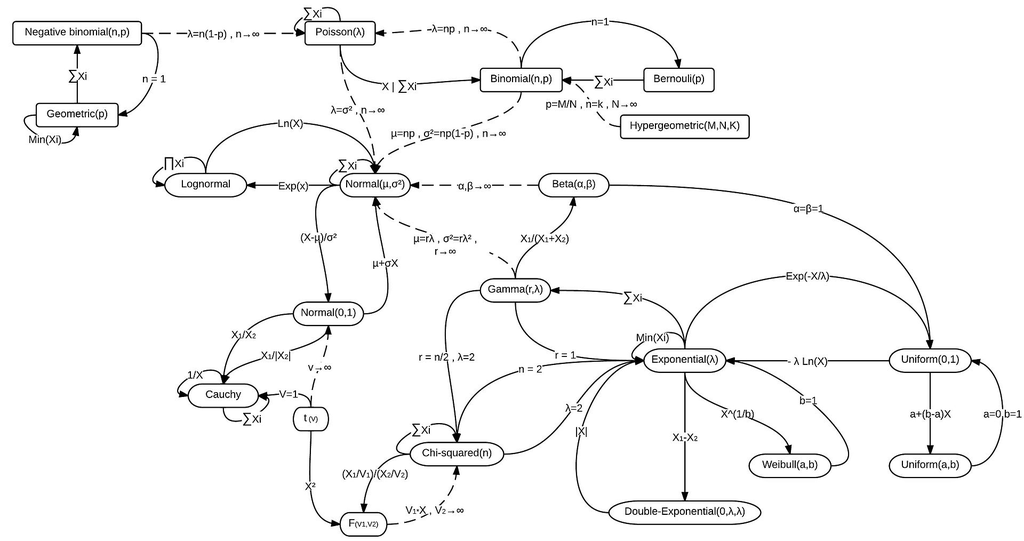

https://en.wikipedia.org/wiki/Relationships_among_probability_distributions

## Linear models and `lm()`

$$y_i = \mu + \alpha_{g_i} + \beta x_j + \epsilon_{ijk}$$

- *linear*: describes the `+`s
- R’s *formulas* are powerful (`model.matrix( )`!!)
- least-squares regression: implies Gaussian noise
- model comparison: with ANOVA and the $F$ test

Random effects / mixed models:

```
ALGAE ~ TREAT + (1|PATCH)
```

# Stepping back

## Steps in data analysis

1. Care, or at least think, about the data.
2. Look at the data.
3. Query the data.
4. Check the answers.
5. Communicate.

What questions are you asking?

well, numbers aren’t racist?

but how we use them might be

More important than statistical technique:

- What questions are being asked?
- What data is being collected? (and how)
- What assumptions are being made?
- What are the important conclusions?

# Models

A $p$-value is:

> the probability of seeing a result at least as surprising as what was observed in the data, if the null hypothesis is true.

A $p$-value is **not**:

> an effect size.

## Bayesian what-not

- bags of biased coins
- probability, and Bayes’ rule
- posterior = prior $\times$ likelihood:
  $$p(\theta | D) = \frac{ p(D | \theta) p(\theta) }{ p(D) }$$
- “updating prior ideas based on (more) data”
- credible intervals
- hierarchical models
- *sharing power* and *shrinkage*
- posterior predictive sampling
- overdispersion: make it random

## MC Stan

- kinda picky
- can climb the posterior likelihood surface (`optimizing( )`)
- or, can skateboard around on it (`sampling( )`)
- needs checking up on

## Examples:

- AirBnB
- pumpkins (ANOVA)
- limpits (mixed models)
- biased coins
- baseball players
- lung cancer survival
- diabetes
- Mauna Loa C02
- ocean temperatures
- hair and eye color
- beer
- wine
- gene expression
- biketown

[figure not shown]

cat

- Austen versus Melville
- blue tit nestlings
- hurricane lizards

## GLMs

*Ingredients:*

- response distribution (“family”)
- inverse link function
- linear predictor

## Stan versus `glm()`/`glmer`

`glm(er)`:

- fast
- easy
- quick
- not so picky about syntax
- uses formulas

`stan`:

- does not sweep convergence issues under the rug
- doesn’t use formulas
- more control, for:
- overdispersion
- hierarchical modeling

`brms`:

- best of both worlds?

My recommendation: get familiar with

https://paul-buerkner.github.io/brms/reference/index.html

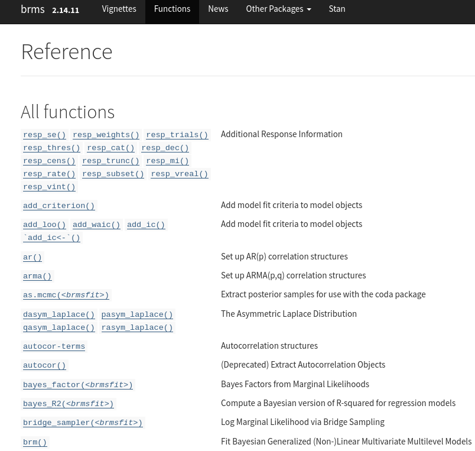

brms function reference

## Things that aren’t obviously models that we did in Stan anyhow

- robust regression: response is Cauchy
- sparse regression: coefficients are Cauchy
- dimension reduction: PCA, t-SNE
- deconvolution: NMF
- spatial smoothing: multivariate Gaussian

## Space and time

*Time series* and *spatial statistics*:

both have to deal with

**autocorrelation.**

*Methods:*

- mechanistic models
- multivariate Normal / Gaussian process / Kriging
- spline / smoothing / loess

# Conclusion

## Be confident!

# Thank you!!!